# WERC Survey: Initial analysis

Author

Diarmuid Lloyd

# Introduction

Summary plots and initial insights from:

- Section A: Experience and impact of WERC
- Section D: The future of WERC

| QID | Question |
| --- | --- |
| QA_1 | How long have you been a member of WERC? |
| QA_2 | How did you ﬁnd out about WERC? |
| QA_3 | What have you enjoyed about being a member? |
| QA_4 | Thinking about the beneﬁts that you have experienced being a member of WERC - what have been your top 3? |
| QA_5 | Is there anything that we could do to further enhance your feeling safe within the club? |
| QA_6 | Is there anything that you feel could be done to improve your overall experience? |
| QA_7 | Are there any special memories or highlights from being involved in the club you would like to share with us? |
| QA_8 | What impact has being a member of WERC had on you? |
| QD_1 | What would be your preferred group size for a typical Thursday night session? |
| QD_2 | How far would you be willing to travel to a session? |
| QD_3 | If we were to split our main Thursday session into smaller groups of runners, which of the following options would you feel comfortable with? |
| QD_4 | And which would be your preferred way to split our main Thursday session? |
| QD_5 | How interested would you be in a 'social run' option as well as our typical interval offering on a Thursday night? |

# Reading data

Data were downloaded from Google Drive and saved locally in the `data/` directory.

# Section A: Experience and impact of WERC

## How long have you been a member of WERC?

**Plot**

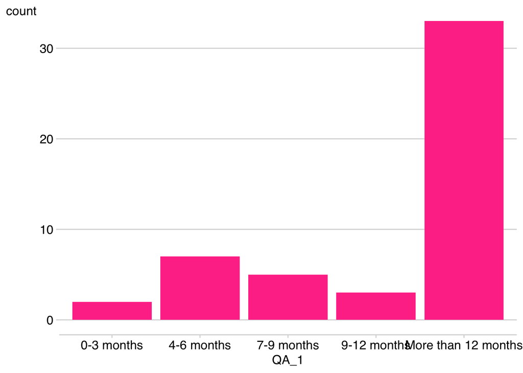

**Table**

| QA_1 | n | percent |
| --- | --- | --- |
| 0-3 months | 2 | 4.0% |
| 4-6 months | 7 | 14.0% |
| 7-9 months | 5 | 10.0% |
| 9-12 months | 3 | 6.0% |
| More than 12 months | 33 | 66.0% |
| Total | 50 | - |

Two-thirds of respondents have been WERC members for more than 12 months. Of the remainder, 16% have been members between 7-12 months, and 18% up to six months.

**Important**

Is this representative of the membership?

## How did you ﬁnd out about WERC?

**Plot**

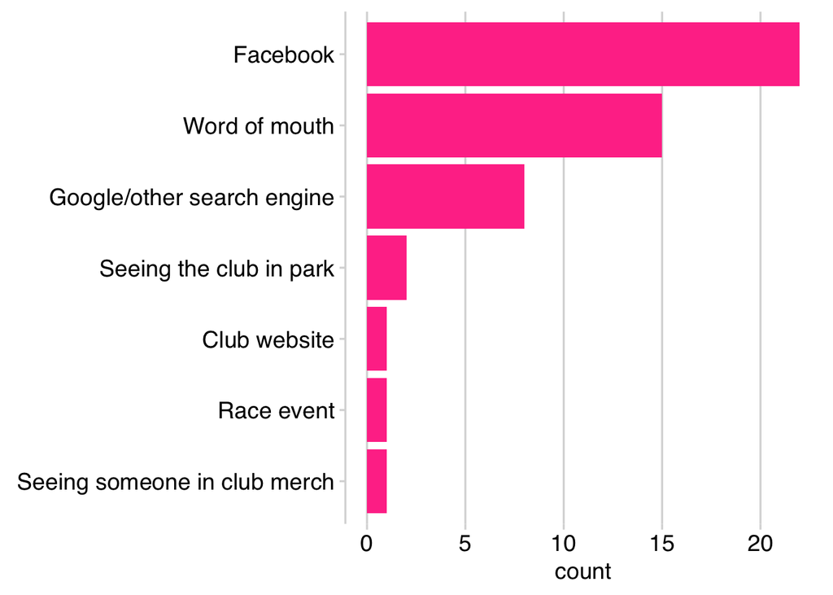

**Table**

| QA_2 | n | percent |
| --- | --- | --- |
| Facebook | 22 | 44.0% |
| Word of mouth | 15 | 30.0% |
| Google/other search engine | 8 | 16.0% |
| Seeing the club in park | 2 | 4.0% |
| Club website | 1 | 2.0% |
| Race event | 1 | 2.0% |
| Seeing someone in club merch | 1 | 2.0% |
| Total | 50 | - |

## Is there a link between time in club and how they heard about it?

**Plot**

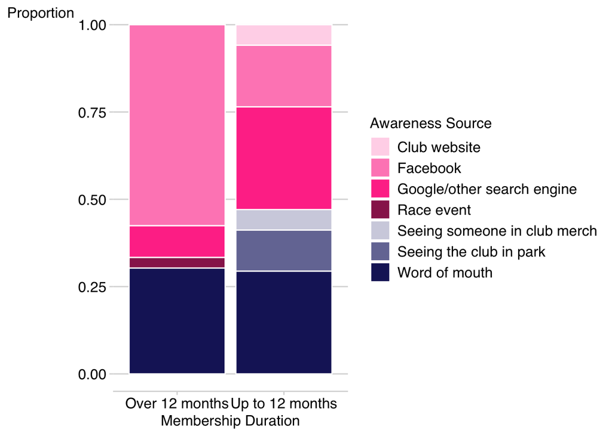

**Table**

**How members heard about WERC by length of membership**

Response counts

| QA_2 | 0-3 months | 4-6 months | 7-9 months | 9-12 months | Up to 12 months (subtotal) | More than 12 months | Total |
| --- | --- | --- | --- | --- | --- | --- | --- |
| Club website | 1 | 0 | 0 | 0 | 1 | 0 | 1 |
| Facebook | 0 | 2 | 1 | 0 | 3 | 19 | 22 |
| Google/other search engine | 1 | 1 | 1 | 2 | 5 | 3 | 8 |
| Race event | 0 | 0 | 0 | 0 | 0 | 1 | 1 |
| Seeing someone in club merch | 0 | 1 | 0 | 0 | 1 | 0 | 1 |
| Seeing the club in park | 0 | 2 | 0 | 0 | 2 | 0 | 2 |
| Word of mouth | 0 | 1 | 3 | 1 | 5 | 10 | 15 |
| Total | 2 | 7 | 5 | 3 | 17 | 33 | 50 |

Source: Club Member Survey (2026)

There’s tentative evidence longer standing members heard about the club through Facebook, but more recent members may have been discovering the club through organic search. This may just reflect that Facebook was the most prominent online presence early in the club’s history: Members may have searched for the club via Google, with the only discoverable channel being Facebook at that time. Recall bias would mean this was answered as “Facebook” when in fact “Google” is what acted as the discovery vector.

Word of mouth is broadly the same proportionally between older and newer members.

We should be very wary of small sample numbers here however, and can bin the results further into broad categories of “internet”, ” in real world (IRL)” and “word of mouth”.

**Important**

Among newwer members, is the higher proportion of hearing about WERC via the website reflective of the time the website has been online?

**Plot**

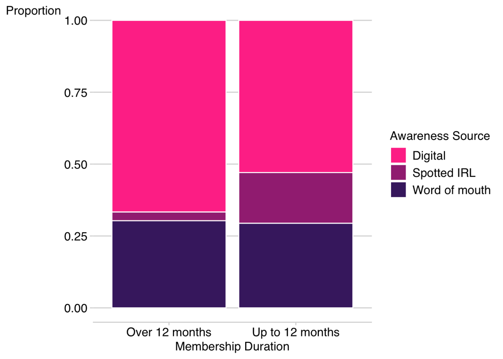

```
    Pearson's Chi-squared test

data:  tab3
X-squared = 3.3403, df = 2, p-value = 0.1882
```

```
                  Digital Spotted IRL Word of mouth
  Over 12 months    20.46        2.64           9.9
  Up to 12 months   10.54        1.36           5.1
```

**Table**

| QA_1_bin_time_group | Digital | Spotted IRL | Word of mouth | Total |
| --- | --- | --- | --- | --- |
| Over 12 months | 22 | 1 | 10 | 33 |
| Up to 12 months | 9 | 3 | 5 | 17 |
| Total | 31 | 4 | 15 | 50 |

After grouping awareness routes into broader categories (Real-world, Digital, Word of mouth), there was no statistically significant association between awareness route and length of membership (χ²(2) = 3.34, p = .19). This suggests that recruitment pathways appear broadly similar across newer and longer-standing members.

## What have you enjoyed about being a member?

This question was an open-ended response, and requires recoding into categories. From a scan of the responses, the coding framework is:

1. Community
2. Coaching
3. Fitness improvement
4. Structured sessions 5 Stretch-environment
5. Locality
6. Culture

The open ended responses mean that responses can fall into multiple categories, as often respondents listed multiple things they enjoyed about the club.

We can use a local LLM (so not sending responses to a Google server or similar) to sift through the text, and assign the responses to one of these categories, and multiple ones.

### Using ellmer to analyse the text

I’ve been trialling using local LLMs, and ellmer provides a really nice interface for this. So, let’s give it a bash. This [article](https://www.mjandrews.org/notes/text_analysis_with_llms/part2.html) has a good summary

We first provide the system prompt.

**Code**

```r
library(ellmer)
system_prompt <- readLines("prompt-club-enjoyment-categorisation.md")
```

**System prompt text**

```
# Context

We have asked members of a running club to complete a survey. One of the
questions is:

"What have you enjoyed about being a member?"

The responses are free text, and can list a number of elements which they enjoy
about being a club member.

# Objective

Your task is to evaluate the free text response provided by each member who
replied, and categorise them into a category picked from the following coding scheme:

1. Community
2. Coaching
3. Fitness improvement
4. Structured sessions
5  Stretch-environment
6. Locality
7. Culture

Your final answer should be one of the numbers listed, and corresponding
description.
```

We now pass this to our LLM (Ollama). Please note, this code-chunk is not evaluated on Render due to the time it takes to process (RIP my Mac). Instead, I’ve run the same code below in a separate script, and instead, we read the outputs of that.

```r
client <- chat_ollama(model = "gemma3:4b", system_prompt = system_prompt)


input_prompts <- as.list(survey_df$QA_3)

chat_output <- parallel_chat_structured(
  chat = client,
  on_error = "return",
  prompts = input_prompts,
  type = type_object(category = type_number(), reasoning = type_string())
)
```